# Praca domowa 2

Karolina Gralak

## Dane

Dane wykorzystane w Pracy domowej 2 są związane z kampaniami marketingu bezpośredniego portugalskiej instytucji bankowej. Kampanie marketingowe opierały się na rozmowach telefonicznych. Często wymagany był więcej niż jeden kontakt z tym samym klientem, aby uzyskać dostęp do tego, czy produkt (lokata bankowa) zostanie (lub nie) subskrybowany. Opis wszystkich kolumn znajduje się również w pliku `README.md`.

#### Dane klienta banku

| Zmienna | Opis |
| --- | --- |
| **age** | wiek |
| **job** : admin., unknown, unemployed, management, housemaid, entrepreneur, student, blue-collar, self-employed, retired, technician, services | administrator, nieznany, bezrobotny, kierownictwo, pokojówka, przedsiębiorca, student, pracownik fizyczny, samozatrudniony, emeryt, technik, usługi |
| **marital** : married, divorced, single; note: divorced means divorced or widowed) | żonaty/zamężna, rozwiedzion_, kawaler/panna; uwaga: rozwiedzion_ oznacza rozwiedzion_ lub owdowiał_ |
| **education** : unknown, secondary, primary, tertiary | nieznane, średnie, podstawowe, wyższe |
| **default** : yes, no | czy kredyt jest niespłacany : tak, nie |
| **balance** : average yearly balance, in euros | średnie roczne saldo w euro |
| **housing** : has housing loan? yes, no | czy posiada kredyt mieszkaniowy? tak, nie |
| **loan** : has personal loan? yes, no | ma pożyczkę osobistą? tak, nie |

#### Dane związane z ostatnim kontaktem w bieżącej kampanii

| Zmienna | Opis |
| --- | --- |
| **contact** : unknown, telephone, cellular | nieznany, telefon, komórkowy |
| **day** : last contact day of the month | dzień miesiąca ostatniego kontaktu |
| **month** : last contact month of year, jan, feb, mar, …, nov, dec | miesiąc ostatniego kontaktu w roku, styczeń, luty, marzec, …, listopad, grudzień |
| **duration** : last contact duration, in seconds | czas trwania ostatniego kontaktu w sekundach |

## Zadanie 1

Weźmy pod uwagę zawody (`job`) klientów banku. Który zawód zacząco wyróżnia się w posiadaniu kredytu mieszkaniowego lub pożyczki osobistej?

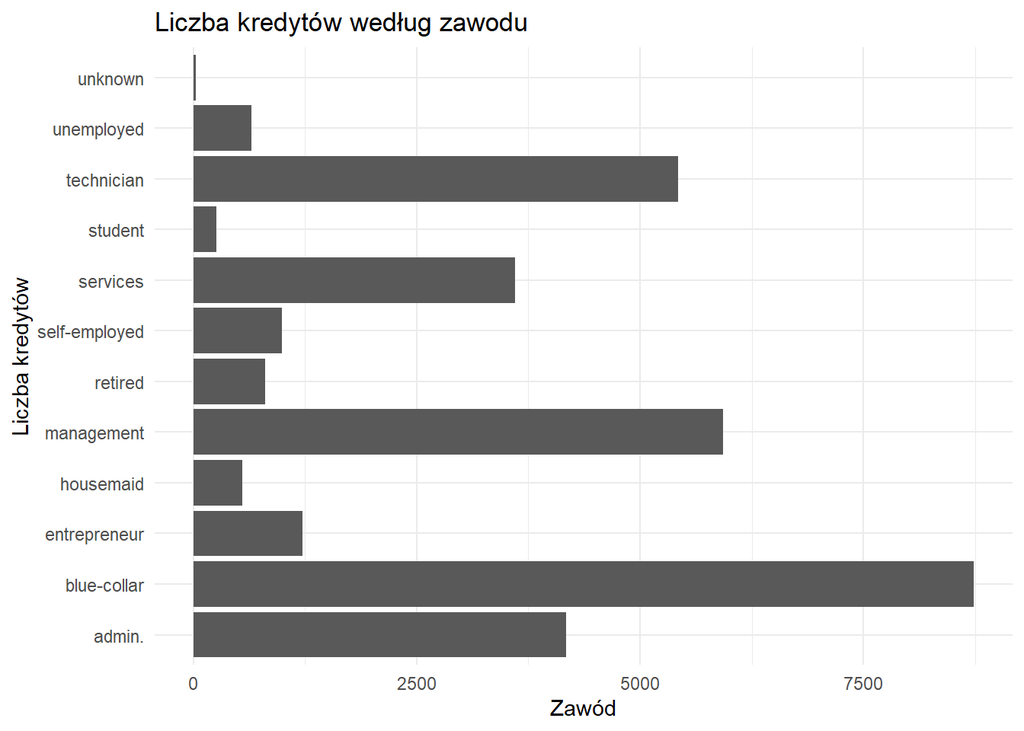

```r
df %>%
  group_by(job) %>%
  summarise(kredyt = sum((housing == "yes") +(loan == "yes"), na.rm = TRUE)) %>%
  ggplot(aes(y = job, x = kredyt)) +
  geom_col() +
  theme_minimal() +
  labs(title = "Liczba kredytów według zawodu",
       x = "Zawód",
       y = "Liczba kredytów")
```

**Komentarz:** Zawód, który posiada najwięcej kredytów lub pożyczek to pracownik fizyczny, a najmniej- nieznany.

## Zadanie 2

Wybierając klientów, którzy mają nieznany sposób kontaktu (`contact`). Jak rozkłada się ich wiek w podziale na status związku?

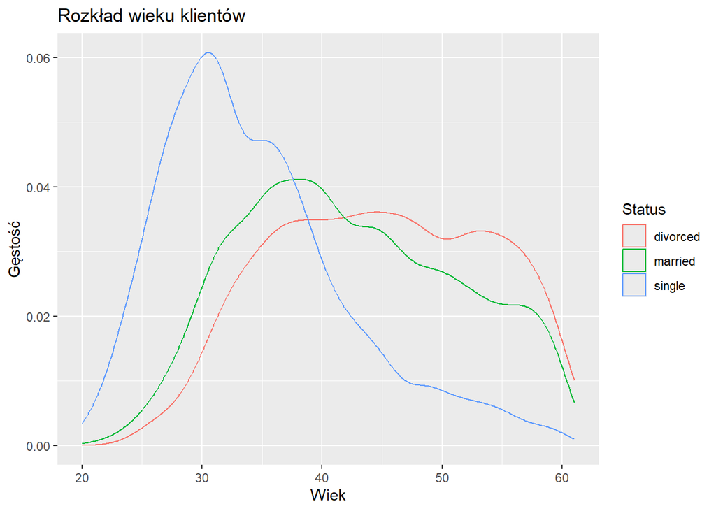

```r
df %>%
  filter(contact == "unknown") %>%
  ggplot(aes(x = age, color = marital)) +
  geom_density()+
  labs(title = "Rozkład wieku klientów",
       x = "Wiek",
       y = "Gęstość",
       color = "Status")
```

**Komentarz:** Spośród singli najwięcej jest 30-latków. Wiek osób rozwiedzionych rozkłada się w miarę równomiernie na przedziale (35, 55), w pozostałych przedziałach osób rozwiedzionych jest mniej. Osób zamężnych/żonatych jest najwięcej w wieku około 37 lat, ale w tym przypadku różnice są mniejsze niż w przypadku singli.

## Zadanie 3

Jaka jest różnica pomiędzy średnim rocznym saldem w euro w zależności od wykształcenia i tego czy kredyt jest niespłacany?

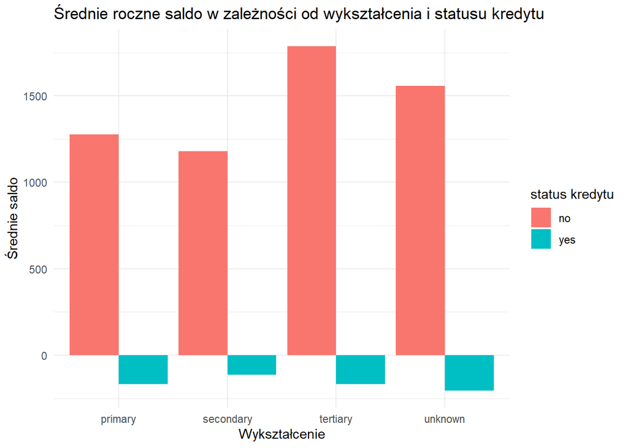

```r
df %>%
  group_by(education, default) %>%
  summarise(saldo = mean(balance, na.rm = TRUE)) %>%
  ggplot(aes(x = education, y = saldo, fill = default)) +
  geom_col(position = "dodge") +
  theme_minimal() +
  labs(title = "Średnie roczne saldo w zależności od wykształcenia i statusu kredytu",
       x = "Wykształcenie",
       y = "Średnie saldo",
       fill = "status kredytu")
```

**Komentarz:** Najwyższe średnie roczne saldo występuje u osób z wykształcenem wyższym i spłacanym kredytem, a najniższe u osób z kykształceniem nieznanym i niespłacanym kredytem.

## Zadanie 4

Czy dzień i miesiąc kontaktu z klientem ma wpływ na średni czas trwania rozmowy w stosunku do średniego czasu trwania rozmowy?

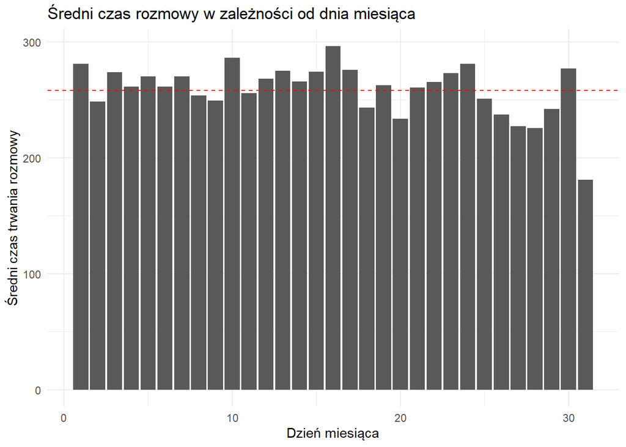

```r
sr_czas <- mean(df$duration)

df1 <- df %>%
  group_by(day) %>%
  summarise(srednia_d = mean(duration))

df2 <- df %>%
  group_by(month) %>%
  summarise(srednia_m = mean(duration))

ggplot(df1, aes(x = day, y = srednia_d))+
  geom_bar(stat = "identity")+
  geom_hline(yintercept = sr_czas, linetype = "dashed", color = "red")+
  labs(title = "Średni czas rozmowy w zależności od dnia miesiąca",
       x = "Dzień miesiąca",
       y = "Średni czas trwania rozmowy") +
  theme_minimal()
```

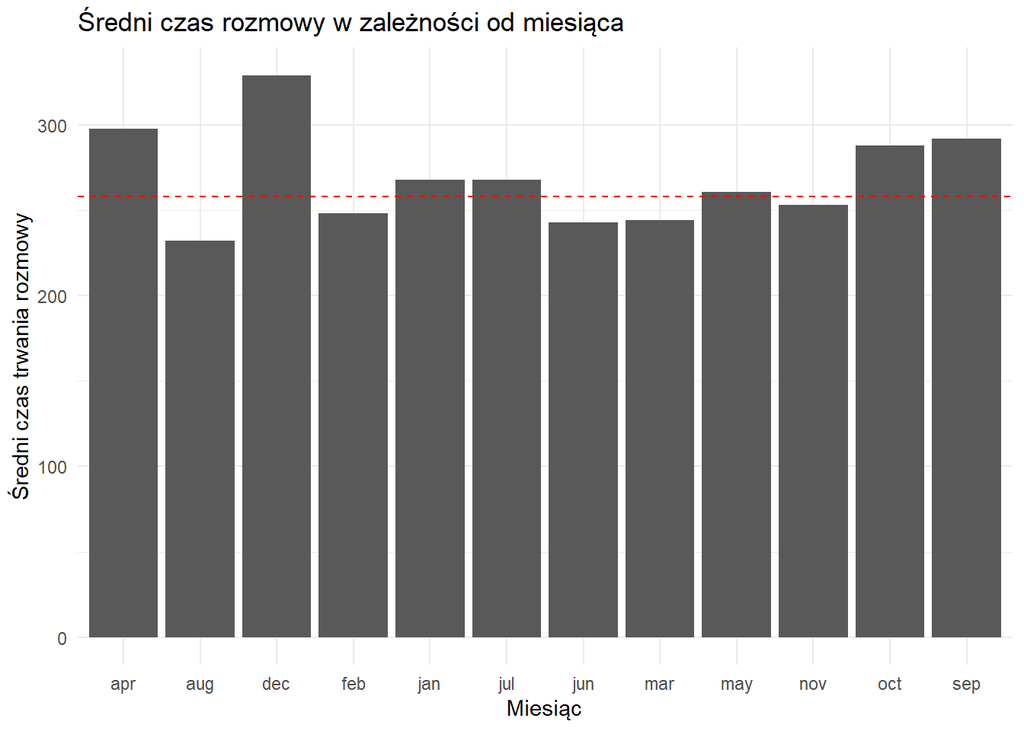

```r
ggplot(df2, aes(x = month, y = srednia_m))+
  geom_bar(stat = "identity")+
  geom_hline(yintercept = sr_czas, linetype = "dashed", color = "red")+
  labs(title = "Średni czas rozmowy w zależności od miesiąca",
       x = "Miesiąc",
       y = "Średni czas trwania rozmowy") +
  theme_minimal()
```

## Zadanie 5

Czy jest zależnośc pomiędzy wiekiem klientów a ich średnim rocznym saldzie w euro w podziale na stopień wykształcenia?

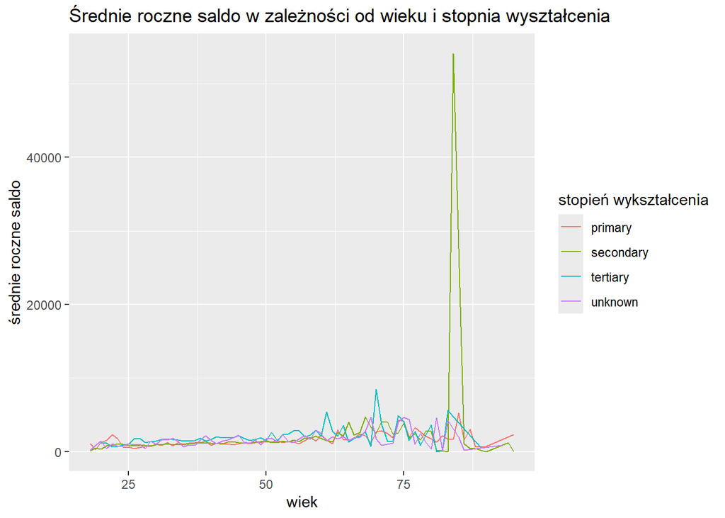

```r
df %>%
  group_by(age, education) %>%
  summarise(saldo = mean(balance)) %>%
  ggplot(aes(x = age, y = saldo, color = education))+
  geom_line()+
  labs(title = "Średnie roczne saldo w zależności od wieku i stopnia wyształcenia",
       x = "wiek",
       y = "średnie roczne saldo",
       color = "stopień wykształcenia")
```

**Komentarz:** Dla osób w wieku poniżej 50 średnie salda osób o różnych stopniach wykształcenia są zbliżone. W wieku około 85 lat można zauważyć znacząca różnicę- saldo dla osób z wykształceniem średnim jest dużo wyższe niz pozostałych.

## Zadanie 6

Rozważmy osoby, które są bezrobotne albo ich zawód jest nieznany. Czy procent osób, które są bezrobotne i nie spłacają kredytu jest większy od procenta osób o nieznanym zawodzie i nie spłacanym kredycie? Jaki typ kredytu jest (przez te osoby) najczęściej niespłacany?

```r
df3 <- df %>%
  filter(job == "unemployed") %>% #osoby bezrobotne, które nie spłacaja kredytu
  summarise(procent_b_n = sum((default == "yes") / n()) * 100)
df3
```

```
##   procent_b_n
## 1    2.302379
```

```r
df4 <- df %>%
  filter(job == "unknown") %>%
  summarise(procent_n_n = sum(default == "yes") / n() * 100)
df4
```

```
##   procent_n_n
## 1   0.6944444
```

```r
df %>%
  filter(job == "unemployed" & default == "yes") %>%
  group_by(loan, housing) %>%
  summarise(count = n())
```

```
## # A tibble: 4 × 3
## # Groups:   loan [2]
##   loan  housing count
##   <chr> <chr>   <int>
## 1 no    no          8
## 2 no    yes        15
## 3 yes   no          2
## 4 yes   yes         5
```

**Komentarz:** Procent osób bezrobotnych i niespłacających kredytu jest większy niż osób o nieznanym zawodzie i niespłacanym kredycie. Przez te osoby najczęściej niespłacany jest kredyt mieszkaniowy.